# Intrinsic Rewards are domain general and related to mental health

# Introduction

Humans spend much of their time engaging in activities that are pleasurable in their own right. These activities are undertaken even when they do not lead to external outcomes: they are intrinsically rewarding. Watching the sunset, reading, solving cross word puzzles, playing, exploring nature, observing works of art, are a few such examples.

On the surface these different activities do not have common features or goals. This contrasts with activities that lead to primary rewards (e.g., eating, fornicating), which all have clear and direct survival benefits, and secondary rewards (e.g., money), which in turn are associated with primary rewards. It is possible, however, that different intrinsic rewards do share core characteristics, mechanisms, and goals not readily transparent. If so, such common features should elicit similar types of behavioural responses, and individual differences in these responses should be partially domain general. Here, we test this hypothesis. Namely, that despite diverse intrinsic rewards seeming vastly different from each other, sensitivity to them is partially domain general and may be shared with secondary rewards.

Engagement with specific intrinsically rewarding stimulus has been associated with happiness, mental health, and professional achievement. Here, we pose that these past findings can in fact be explained by a core association between mental health and domain-general sensitivity to intrinsic rewards. That is, if an individual finds a specific stimulus rewarding (e.g. observing landscapes), they may be more likely to find other stimuli (e.g. reading, playing, etc.) rewarding due to a domain-general sensitivity to (intrinsic) rewards, which may be associated with mental health. Individuals with high sensitivity to intrinsic rewards will be inclined to engage with a variety of seemingly diverse intrinsically rewarding activities, which in turn will increase the likelihood that they will eventually find rewarding activities that they also excel at. Low sensitivity to intrinsic rewards, on the other hand, will produce a general disinterest in a large variety of activities, which will lead to low mood and lack of motivation. Thus, a domain-general sensitivity to intrinsic rewards will contribute to flourishing and its absence to suffering.

We focus here on a core aspect of mental health which we will refer to as ‘affective health’. We define ‘affective health’ as a range of characteristics that are related to positive mood, high motivation, feelings of pleasure, interest, and happiness. To investigate whether sensitivity to intrinsic rewards is domain general and related to affective aspects of mental health, we selected three putative intrinsically rewarding** stimuli from the visual domain, cognitive domain, and social domain, (Fig 1A). We also compared responses to these putative intrinsic rewards with responses to monetary reward, to test whether sensitivity to intrinsic rewards is shared with that to secondary rewards.

It has been suggested that a stimulus is a ‘reward’ if it elicits three typical responses. First, it elicits positive emotions (it is ‘liked’). Second, it generates approach/consummatory behaviours (it is ‘wanted’). Third, it increases the likelihood of the action that led to it (it is ‘reinforcing’). Thus, we measured liking, wanting and reinforcement of all stimuli to assess individuals’ reward sensitivity. We also asked participants to fill a range of questionnaires related to affective aspects of mental health and implemented a dimensionality approach, which considers the possibility that specific symptoms is predictive of several conditions, thus allowing an investigation that cuts through classic clinical boundaries. Together, the data allowed us to examine if within-individual responses to intrinsic rewards are domain general and linked to mental health.

# Participants number & Demographics summary

## Experiment 1

```r
# power analysis
pwr.r.test(r=0.25,power=0.80,sig.level=0.05,alternative="two.sided")
```

```
##
##      approximate correlation power calculation (arctangh transformation)
##
##               n = 122.4466
##               r = 0.25
##       sig.level = 0.05
##           power = 0.8
##     alternative = two.sided
```

```r
# Demo
print(lDemo1 %>%
  mutate(gender = ifelse(is.na(gender), "Unknown", ifelse(gender == 0, "Female", "Male"))) %>%
  group_by(gender) %>%
  summarize(
    Proportion = n() / nrow(lDemo1),
    Average_Age = mean(age, na.rm = TRUE),
    SD_Age = sd(age, na.rm = TRUE),
    Average_IQ = mean(iq, na.rm = TRUE),
    SD_IQ = sd(iq, na.rm = TRUE),
    Average_Edu = mean(edu, na.rm = TRUE),
    SD_Edu = sd(edu, na.rm = TRUE),
    Average_Married = mean(married, na.rm = TRUE),
    SD_Married = sd(married, na.rm = TRUE)
  ))
```

```
## # A tibble: 2 × 10
##   gender Proportion Averag…¹ SD_Age Avera…² SD_IQ Avera…³ SD_Edu Avera…⁴ SD_Ma…⁵
##   <chr>       <dbl>    <dbl>  <dbl>   <dbl> <dbl>   <dbl>  <dbl>   <dbl>   <dbl>
## 1 Female      0.341     33.0  12.0     7.91  3.31    3.31   1.55   0.356   0.484
## 2 Male        0.659     28.7   9.16    8.79  3.46    3.03   1.60   0.391   0.491
## # … with abbreviated variable names ¹Average_Age, ²Average_IQ, ³Average_Edu,
## #   ⁴Average_Married, ⁵SD_Married
```

## Experiment 2

```r
# power analysis
pwr.r.test(r=0.22,power=0.80,sig.level=0.05,alternative="two.sided")
```

```
##
##      approximate correlation power calculation (arctangh transformation)
##
##               n = 159.0316
##               r = 0.22
##       sig.level = 0.05
##           power = 0.8
##     alternative = two.sided
```

```r
# Demo
print(lDemo2 %>%
  mutate(gender = ifelse(is.na(gender), "Unknown", ifelse(gender == 0, "Female", "Male"))) %>%
  group_by(gender) %>%
  summarize(
    Proportion = n() / nrow(lDemo2),
    Average_Age = mean(age, na.rm = TRUE),
    SD_Age = sd(age, na.rm = TRUE),
    Average_IQ = mean(iq, na.rm = TRUE),
    SD_IQ = sd(iq, na.rm = TRUE),
    Average_Edu = mean(edu, na.rm = TRUE),
    SD_Edu = sd(edu, na.rm = TRUE),
    Average_Married = mean(married, na.rm = TRUE),
    SD_Married = sd(married, na.rm = TRUE)
  ))
```

```
## # A tibble: 2 × 10
##   gender Proportion Averag…¹ SD_Age Avera…² SD_IQ Avera…³ SD_Edu Avera…⁴ SD_Ma…⁵
##   <chr>       <dbl>    <dbl>  <dbl>   <dbl> <dbl>   <dbl>  <dbl>   <dbl>   <dbl>
## 1 Female      0.509     33.7   15.6    7.25  3.31    2.98   1.49   0.391   0.491
## 2 Male        0.491     34.8   12.8    8.29  2.99    3.11   1.70   0.369   0.485
## # … with abbreviated variable names ¹Average_Age, ²Average_IQ, ³Average_Edu,
## #   ⁴Average_Married, ⁵SD_Married
```

## Experiment 3

```r
# power analysis
pwr.r.test(r=0.22,power=0.80,sig.level=0.05,alternative="two.sided")
```

```
##
##      approximate correlation power calculation (arctangh transformation)
##
##               n = 159.0316
##               r = 0.22
##       sig.level = 0.05
##           power = 0.8
##     alternative = two.sided
```

```r
# Demo
print(lDemo3 %>%
  mutate(gender = ifelse(is.na(gender), "Unknown", ifelse(gender == 0, "Female", "Male"))) %>%
  group_by(gender) %>%
  summarize(
    Proportion = n() / nrow(lDemo3),
    Average_Age = mean(age, na.rm = TRUE),
    SD_Age = sd(age, na.rm = TRUE),
    Average_IQ = mean(iq, na.rm = TRUE),
    SD_IQ = sd(iq, na.rm = TRUE),
    Average_Edu = mean(edu, na.rm = TRUE),
    SD_Edu = sd(edu, na.rm = TRUE),
    Average_Married = mean(married, na.rm = TRUE),
    SD_Married = sd(married, na.rm = TRUE)
  ))
```

```
## # A tibble: 2 × 10
##   gender Proportion Averag…¹ SD_Age Avera…² SD_IQ Avera…³ SD_Edu Avera…⁴ SD_Ma…⁵
##   <chr>       <dbl>    <dbl>  <dbl>   <dbl> <dbl>   <dbl>  <dbl>   <dbl>   <dbl>
## 1 Female      0.406     38.4   11.7    7.93  3.37    3.32   1.64   0.562   0.500
## 2 Male        0.594     38.7   11.6    8.43  3.69    3.29   1.73   0.589   0.494
## # … with abbreviated variable names ¹Average_Age, ²Average_IQ, ³Average_Edu,
## #   ⁴Average_Married, ⁵SD_Married
```

For all experiments, ethical approval was provided by the Research Ethics Committee at University College London (Project ID Number:3990/003) and all participants gave written informed consent to participate.

One hundred and fourty nine participants completed the task on Prolific (https://www.prolific.co/) online system. 17 participants failed the comprehension and/or attention checks, thus their data was not analysed (see details below). Thus, data of 132 participants were analysed (female = 34%, age = 33 ± 12 (M ± SD); male = 66%, age = 29 ± 9; other = 0%). Participants received £7.50 per hour for their participation plus a 50p “bonus” payment. The experiment lasted for about 90 minutes. For all experiments, ethical approval was provided by the Research Ethics Committee at University College London and all participants gave written informed consent to participate.

Participants (Experiment 2). Sample size was based on a power analysis based on Experiment 1, which showed that 159 participants were required for a regression weight of 0.22 (lower bound of the effect size from the regression between mental health score and reward sensitivity, without correcting for demographics, which was 0.23 ± 0.01 in Experiment 1) with 80% power and alpha = 0.05. We anticipated that about 30 participants will fail the attention and/or comprehension checks. Therefore, we recruited 188 participants on the Prolific website. Data of 17 participants were not analysed as they did not pass the comprehension and/or attention checks. Thus, 171 participant’s data was analysed (female = 51%, age = 34 ± 16 (M ± SD); male = 49%, age = 35 ± 13; other = 0%). Participants received £7.50 per hour for their participation. Data were collected between January 20th 2022 and January 25th 2022.

Participants (Experiment 3). Data was collected between January 18th 2023 and January 31st 2023. Sample size was calculated as for Experiment 2. As we added more catch trials (in the wanting measure, see below), we expected a higher rate of failure at the attention checks. Therefore, we added about an extra 40 participants and we therefore recruited 198 participants on Prolific website. Data of 18 participants was not analysed as they did not pass comprehension and/or attention checks. Thus, 180 participant’s data was analysed (female = 41%, age = 38 ± 12 (M ± SD); male = 59%, age = 39 ± 12; other = 0%).

# Results

Two identical online studies were conducted (Experiment 1: N = 132, Experiment 2: N = 171), as well as a modified version (Experiment 3: N = 180). In each we measured three types of responses: liking, wanting, and reinforcing strength (in that order in Experiment 1&2, and counterbalanced in Experiment 3, see Methods) to ten categories of stimuli. There were three categories of putative intrinsic reward (visual, cognitive, social) and three categories of non-rewarding alternative stimuli (visual, cognitive, social). In the visual domain, we used landscapes as a reward and images of walls as an alternative (Figure 1A & Methods). Staring at landscapes has been rated positively in the past unlike looking at walls7,17. In the cognitive domain, we presented participants with trivia facts, as consuming such information (e.g. reading) is thought to be rewarding9,10. It has been shown that humans select to observe (and thus read) sentences and that the opportunity to consume sentences that increase general knowledge activates the reward system just like primary rewards, suggesting that consuming knowledge is rewarding9,10. We presented random string of letters as an alternative. In the social domain, we used social similarity as a reward (i.e. a participant learns that another participant shares the same preference as them) and social disagreement as an alternative. This was selected as studies have shown the existence of a confirmation bias by which subjects select to observe information that they suspect confirms their believes (e.g. 18) including in the social domain11. Moreover, confirmation has been shown to activate the reward system 11, suggesting that consuming confirmatory information (e.g., learning that someone agrees with you) is rewarding. The monetary reward was earning bonus money (represented on screen as a coin) and its alternative was not receiving a coin. All reward types were compared to a neutral stimulus: vertical and horizontal lines.

To measure liking, participants were exposed to a block of a rewarding stimulus and to a block of its alternative and were asked to report how much they liked that block after each block (Figure 1B & Methods). To measure wanting in Experiment 1 & 2, participants indicated whether they preferred to experience ten trials of the reward or ten trials of its control on a sliding preference scale, which deterministically and explicitly led to the presentation of either ten trials of the putative intrinsically rewarding stimulus or its alternative. In Experiment 3, on each of 15 trials participants chose whether to be exposed to a rewarding stimulus or to its alternative and their choice was immediately honoured. To measure reinforcing strength, that is whether a stimulus increase the likelihood of the action that preceded them, participants chose between abstract shapes probabilistically linked to the putative intrinsically rewarding stimulus or to the corresponding alternative.

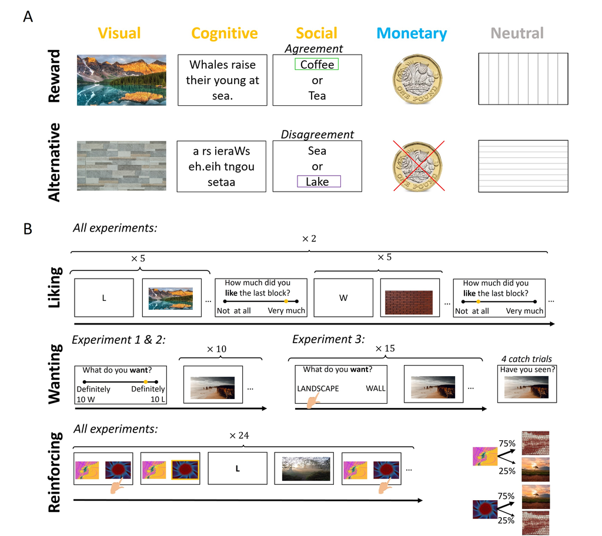

Figure 1. Experimental design. A: Stimuli included five categories –visual, cognitive, social and monetary rewards as well as neutral stimuli. Intrinsic rewards were the visual reward (landscapes), the cognitive reward (facts) and the social reward (social approbation of participant’s preference which was collected at the beginning of the experiment). The monetary reward was a coin signalling a bonus payment. It was always the same coin in Experiment 1 & 2, but different coins on every trial in Experiment 3. Each reward was associated with an alternative stimulus. This included walls for the visual reward, a random string of letters for the cognitive reward, disagreement for the social reward, and not receiving a coin for the secondary reward. Neutral stimuli were vertical and horizontal lines. B: For each reward type, participants were exposed to two blocks of the rewarding stimulus (five trials each) and two blocks of the alternative stimulus (five trials each). Order was either reward-alternative-reward-alternative or alternative-reward-alternative-reward. After each block participants rated how much they liked that block. To measure wanting in Experiment 1 & 2, participants were asked to rate how much they wanted to be exposed to 10 trials of the rewarding stimulus or 10 trials of the alternative stimulus. They were then exposed to ten trials of the chosen stimulus. In Experiment 3, on each of 15 trials participants chose whether to be exposed to a rewarding stimulus or the alternative stimuli, and then their choice was honoured. To measure the reinforcing strength of each reward, participants were exposed to a pair of abstract cues each probabilistically related to the rewarding stimulus with either 0.75 probability or 0.25 probability and to the alternative stimulus with either 0.25 or 0.75 probability. The percentage of trials in which they selected the abstract cue leading more often to the rewarding stimulus was the measure of the reinforcing strength. Each reward type was presented in counterbalanced order across participants for all experiments. In Experiment 1 & 2, the order was always liking-wanting-reinforcement, while in Experiment 3 the order was counterbalanced across participants and reward type. In this figure we use landscapes (L) and walls (W) as example trials.

# Intrinsic rewards are liked, wanted, and reinforcing

## Experiment 1

### Liking Rating

```
##           Stimulus Avg_Reward_Rating SE_Reward_Rating Avg_Alternative_Rating
## LikingVR    Visual          83.00000         1.484304               42.09848
## LikingCR Cognitive          79.38636         1.380679               22.95455
## LikingSR    Social          70.48864         1.504691               47.84848
## LikingMR  Monetary          88.71212         1.432357               15.34091
## LikingNV   Neutral          55.45076         1.764459               52.64394
##          SE_Alternative_Rating  Diff_Avg  SE_Diff   r_value      p_value
## LikingVR              1.857563 40.901515 2.377750 1.0555440 7.572594e-34
## LikingCR              1.629195 56.431818 2.135544 1.1900019 1.490706e-42
## LikingSR              1.607248 22.640152 2.201668 0.7991098 4.268166e-20
## LikingMR              1.618956 73.371212 2.161635 1.2118256 4.603974e-44
## LikingNV              1.856676  2.806818 2.561359 0.0964446 2.678341e-01
```

```
##                  Wall  Letters Disconfirmation   NoCoin Horizontal
## Landscape    40.9±2.3   60±2.3        35.2±2.1 67.7±2.3   30.4±2.2
## Information  37.3±2.3 56.4±2.5        31.5±2.2   64±2.2   26.7±2.1
## Confirmation 28.4±2.3 47.5±2.3          22.6±2 55.1±2.5     17.8±2
## Coin         46.6±2.3 65.8±2.4        40.9±2.1 73.4±2.7   36.1±2.2
## Vertical     13.4±2.3 32.5±2.2         7.6±2.3 40.1±2.4    2.8±1.2
```

```
##              [,1]         [,2]         [,3]         [,4]         [,5]
## [1,] 6.499451e-23 2.556508e-23 9.979261e-22 2.350370e-23 1.125007e-19
## [2,] 4.348677e-22 4.746051e-23 9.932733e-21 3.168548e-23 1.179401e-19
## [3,] 1.037996e-18 3.304762e-23 1.954347e-20 6.342825e-23 3.098870e-15
## [4,] 2.365365e-23 3.250589e-23 7.785419e-23 1.989862e-23 6.170699e-21
## [5,] 1.643340e-07 1.998238e-21 5.888464e-03 8.292334e-22 1.094727e-01
```

```
##                 Reward (M)      Reward (SE)                 r
## Visual     38.094696969697 2.56825139687677 0.816909633931286
## Cognitive           53.625 2.76874081797026 0.847398266959071
## Social    19.8333333333333 2.24459065659379 0.694539505702027
## Monetary  70.5643939393939 2.91032607110084  0.86516128119197
##                        p-value NA
## Visual    6.25728041255358e-21
## Cognitive 2.12006493340596e-22
## Social    1.46747143594525e-15
## Monetary  2.78977324521622e-23
```

### Wanting Rating

```
##           Stimulus Avg_Reward_Rating SE_Reward_Rating    r_value      p_value
## WantingV    Visual          87.62121        1.8149892 0.82336741 3.086172e-21
## WantingC Cognitive          93.42424        1.4583080 0.87630777 7.651065e-24
## WantingS    Social          75.56061        2.1638113 0.70042845 8.463349e-16
## WantingM  Monetary          97.30303        0.8802942 0.94944632 1.051964e-27
## WantingN   Neutral          50.76515        2.3049359 0.01813633 8.349396e-01
```

### Reinforcement (proportion of best choice)

```
##            Stimulus Avg_Reward_Rating SE_Reward_Rating    r_value      p_value
## LearningV    Visual          73.98990         1.936795 0.72334133 9.525212e-17
## LearningC Cognitive          76.60985         1.861475 0.76281367 1.883385e-18
## LearningS    Social          68.84470         2.001720 0.63174693 3.922185e-13
## LearningM  Monetary          77.71465         1.718057 0.79720393 5.229515e-20
## LearningN   Neutral          51.86237         2.408677 0.06225383 4.744595e-01
```

## Experiment 2

### Liking Rating

```
##           Stimulus Avg_Reward_Rating SE_Reward_Rating Avg_Alternative_Rating
## LikingVR    Visual          84.18713         1.239889               40.32456
## LikingCR Cognitive          76.04971         1.486423               20.98830
## LikingSR    Social          68.08480         1.379409               46.70468
## LikingMR  Monetary          87.42398         1.315437               16.84795
## LikingNV   Neutral          50.84503         1.720045               50.46199
##          SE_Alternative_Rating   Diff_Avg  SE_Diff    r_value      p_value
## LikingVR              1.614309 43.8625731 2.035514 1.25316033 5.348186e-47
## LikingCR              1.517896 55.0614035 2.124491 1.28555426 2.290729e-49
## LikingSR              1.457379 21.3801170 2.006670 0.86918356 1.752412e-23
## LikingMR              1.494561 70.5760234 1.991002 1.36775147 1.207680e-55
## LikingNV              1.755835  0.3830409 2.457948 0.04638305 5.941024e-01
```

```
##                  Wall  Letters Disconfirmation   NoCoin Horizontal
## Landscape    43.9±2.1 63.2±2.2        37.5±1.9 67.3±2.1     33.7±2
## Information  35.7±2.2 55.1±2.2        29.3±1.9 59.2±2.1   25.6±2.3
## Confirmation 27.8±2.1 47.1±1.9        21.4±1.6   51.2±2   17.6±2.1
## Coin         47.1±2.2 66.4±2.2          40.7±2 70.6±2.4     37±2.2
## Vertical       10.5±2 29.9±2.1         4.1±2.1   34±2.2    0.4±1.1
```

```
##              [,1]         [,2]         [,3]         [,4]         [,5]
## [1,] 2.597151e-29 2.676324e-29 1.752830e-27 1.169539e-29 1.597064e-26
## [2,] 2.782689e-25 1.704418e-29 8.099034e-24 1.931394e-29 6.578469e-19
## [3,] 5.703580e-22 5.733618e-29 1.562062e-24 6.499258e-29 1.052679e-14
## [4,] 1.749657e-28 1.677844e-29 1.059206e-27 6.142535e-30 2.035599e-26
## [5,] 1.316356e-07 3.235747e-23 5.447765e-02 1.217774e-24 4.348945e-01
```

```
##                 Reward (M)      Reward (SE)                 r
## Visual    43.4795321637427 2.36042198831836 0.840494560846196
## Cognitive 54.6783625730994 2.36967722254049  0.86054184866802
## Social    20.9970760233918 1.75529322373021 0.747589232712851
## Monetary  70.1929824561404 2.55620770923119 0.859369365923399
##                        p-value NA
## Visual    4.22724796458807e-28
## Cognitive 2.23732604199454e-29
## Social    1.42743845352478e-22
## Monetary  2.66190091979264e-29
```

### Wanting Rating

```
##           Stimulus Avg_Reward_Rating SE_Reward_Rating    r_value      p_value
## WantingV    Visual          90.21637        1.4950094 0.85276395 7.053954e-29
## WantingC Cognitive          92.95906        1.3932452 0.89549020 1.132077e-31
## WantingS    Social          75.15789        1.8532016 0.69072851 1.678746e-19
## WantingM  Monetary          96.32749        0.8749399 0.93712810 1.588479e-34
## WantingN   Neutral          50.78363        1.9817623 0.03382637 6.582452e-01
```

### Reinforcement (proportion of best choice)

```
##            Stimulus Avg_Reward_Rating SE_Reward_Rating    r_value      p_value
## LearningV    Visual          72.44152         1.706210 0.69513051 9.902913e-20
## LearningC Cognitive          74.82943         1.764743 0.72219878 3.589012e-21
## LearningS    Social          65.78947         1.817050 0.54708466 8.424808e-13
## LearningM  Monetary          76.92495         1.537947 0.77930892 2.179935e-24
## LearningN   Neutral          51.36452         2.041660 0.04484663 5.575760e-01
```

## Experiment 3

### Liking Rating

```
##           Stimulus Avg_Reward_Rating SE_Reward_Rating Avg_Alternative_Rating
## LikingVR    Visual          83.79722         1.143076               39.27778
## LikingCR Cognitive          78.11667         1.260604               16.30556
## LikingSR    Social          74.55000         1.128252               39.80556
## LikingMR  Monetary          71.38056         1.469240               17.21667
## LikingNV   Neutral          47.12500         1.602585               45.13333
##          SE_Alternative_Rating  Diff_Avg  SE_Diff   r_value      p_value
## LikingVR              1.444393 44.519444 1.841980 1.3053875 7.593850e-51
## LikingCR              1.308381 61.811111 1.816861 1.3910035 1.721963e-57
## LikingSR              1.293201 34.744444 1.716194 1.2395829 5.046701e-46
## LikingMR              1.526987 54.163889 2.119046 1.3123540 2.266987e-51
## LikingNV              1.682751  1.991667 2.323775 0.0999986 2.505987e-01
```

```
##                  Wall  Letters Disconfirmation   NoCoin Horizontal
## Landscape      44.5±2   67.5±2          44±1.9 66.6±2.2     38.7±2
## Information    38.8±2 61.8±2.1          38.3±2 60.9±2.2       33±2
## Confirmation   35.3±2   58.2±2        34.7±1.9 57.3±2.1   29.4±1.9
## Coin         32.1±2.1 55.1±2.1        31.6±2.1 54.2±2.3   26.2±2.2
## Vertical        7.8±2 30.8±1.9           7.3±2 29.9±2.1      2±1.6
```

```
##              [,1]         [,2]         [,3]         [,4]         [,5]
## [1,] 3.048024e-30 4.435244e-31 5.841219e-30 1.536103e-30 7.291886e-30
## [2,] 4.194707e-29 6.643387e-31 1.687948e-28 2.698873e-30 2.142513e-28
## [3,] 1.795047e-28 9.877407e-31 1.671549e-29 3.233214e-30 2.034969e-27
## [4,] 3.892153e-25 7.937028e-31 3.355764e-26 2.222090e-30 2.737935e-21
## [5,] 1.439991e-05 1.179225e-26 6.682362e-04 1.171069e-22 8.553531e-02
```

```
##                 Reward (M)      Reward (SE)                 r
## Visual    42.5277777777778 2.58225850837387 0.827665647986341
## Cognitive 59.8194444444444 2.63485672377541 0.854149066858746
## Social    32.7527777777778 2.50978685597365 0.783820431765336
## Monetary  52.1722222222222 2.83766052035376 0.836867997617191
##                        p-value NA
## Visual    1.19550521058323e-28
## Cognitive 2.10454853225198e-30
## Social    7.28610391096101e-26
## Monetary  2.97928005503532e-29
```

### Wanting proportion

```
##           Stimulus Avg_Reward_Rating SE_Reward_Rating    r_value      p_value
## WantingV    Visual          83.55556         1.945105 0.77547417 2.375449e-25
## WantingC Cognitive          94.40741         1.029483 0.89967587 1.513627e-33
## WantingS    Social          80.62963         1.808622 0.76659533 8.238004e-25
## WantingM  Monetary          92.03704         1.103134 0.89649077 2.541860e-33
## WantingN   Neutral          52.51852         2.601233 0.07583735 3.089323e-01
```

### Reinforcement (proportion of best choice)

```
##            Stimulus Avg_Reward_Rating SE_Reward_Rating    r_value      p_value
## LearningV    Visual          73.58796         1.835468 0.66989988 2.525727e-19
## LearningC Cognitive          81.41204         1.416685 0.80389283 4.036856e-27
## LearningS    Social          73.07870         1.962090 0.63481943 1.637447e-17
## LearningM  Monetary          80.18519         1.393004 0.80038657 6.726242e-27
## LearningN   Neutral          49.39815         2.388119 0.02402735 7.471795e-01
```

# Factor Analysis on questionnaires

## Experiment 1

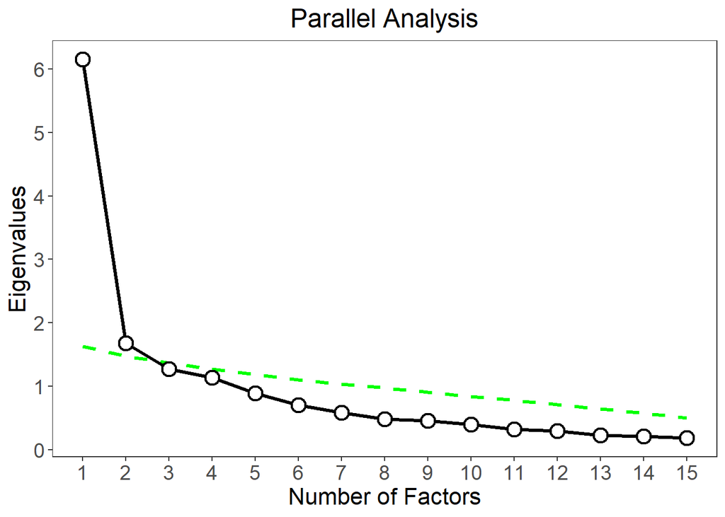

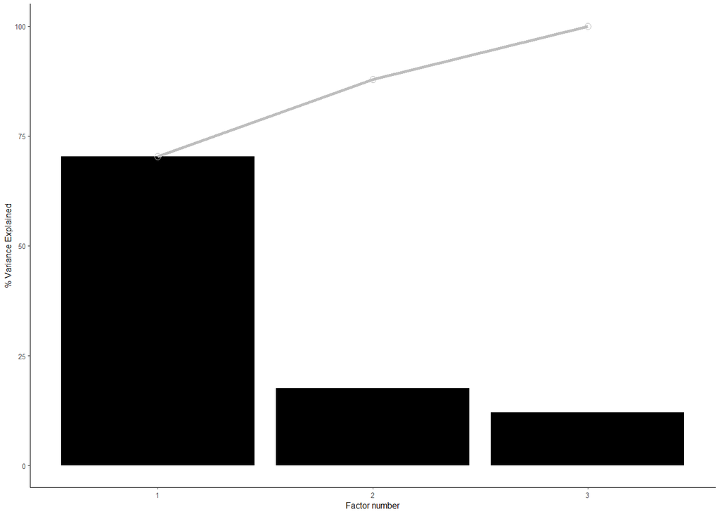

## Experiment 2

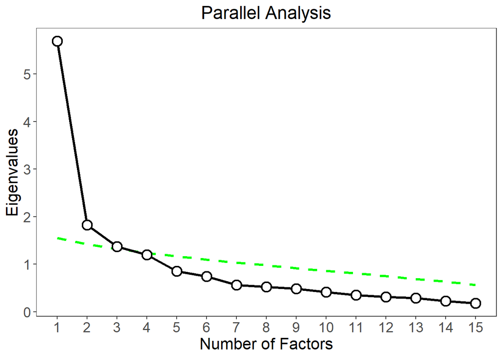

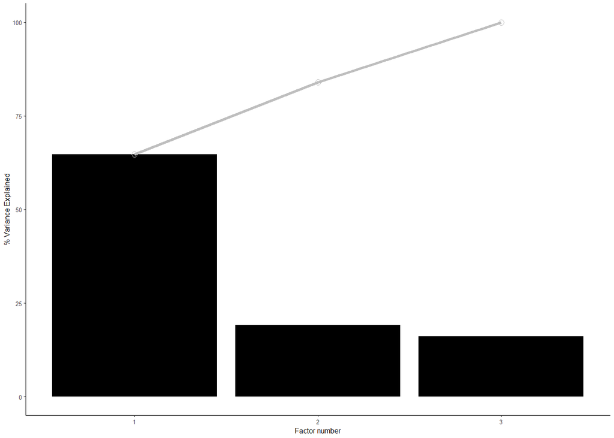

## Experiment 3

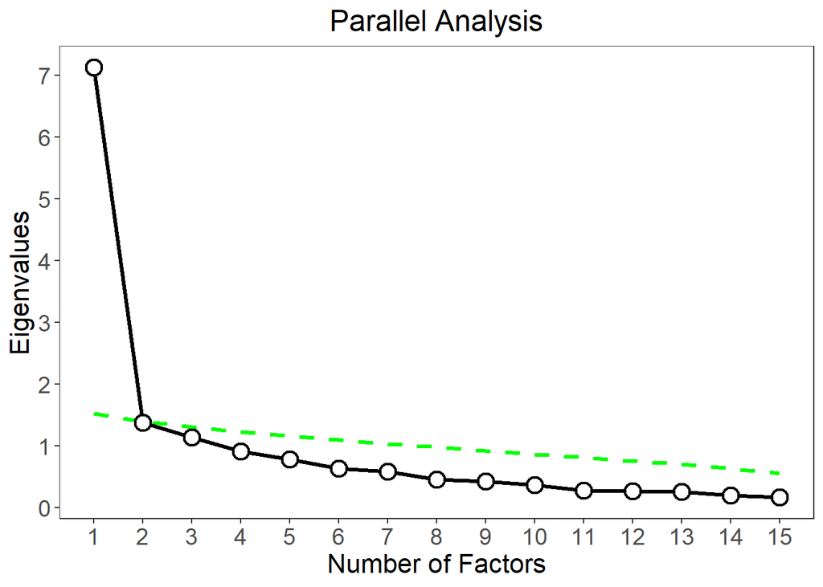

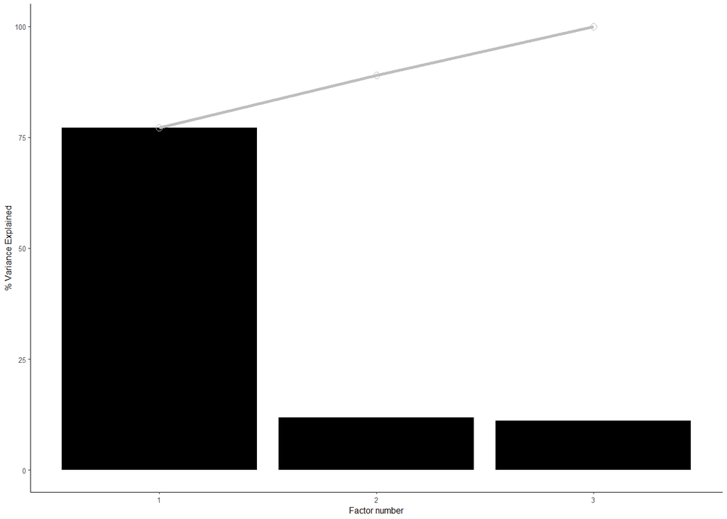

# Reward sensitivity is partially domain general

Next, we tested whether the sensitivity to intrinsic reward is domain general. In other words, if a particular participant finds the visual reward rewarding, will they be more likely to find the cognitive and the social reward rewarding? Will they also find the monetary reward more rewarding? Next, we asked whether the ‘reward sensitivity’ score is related to affective aspects of mental health. That is, do people with high reward sensitivity experience better affective health?

# Reward data factorability

## Experiment 1

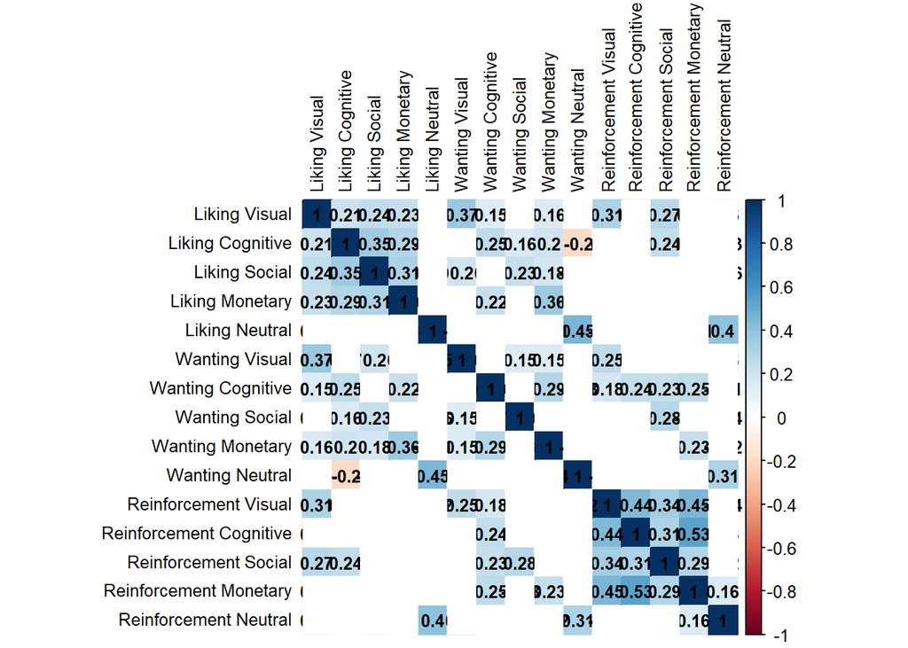

```
## R was not square, finding R from data
```

```
## $chisq
## [1] 378.1741
##
## $p.value
## [1] 1.651749e-32
##
## $df
## [1] 105
```

```
## [1] 0.04873468
```

```
## Kaiser-Meyer-Olkin factor adequacy
## Call: KMO(r = cor(lStim1))
## Overall MSA =  0.63
## MSA for each item =
##   LikingV   LikingC   LikingS   LikingM   LikingN  WantingV  WantingC  WantingS
##      0.59      0.73      0.71      0.70      0.53      0.54      0.84      0.44
##  WantingM  WantingN LearningV LearningC LearningS LearningM LearningN
##      0.69      0.60      0.68      0.68      0.67      0.57      0.55
```

```
## Kaiser-Meyer-Olkin factor adequacy
## Call: KMO(r = cor(lStim2))
## Overall MSA =  0.64
## MSA for each item =
##   LikingV   LikingC   LikingS   LikingM   LikingN  WantingV  WantingC  WantingS
##      0.65      0.70      0.76      0.74      0.65      0.56      0.65      0.51
##  WantingM  WantingN LearningV LearningC LearningS LearningM LearningN
##      0.54      0.60      0.64      0.68      0.60      0.68      0.54
```

```
## Kaiser-Meyer-Olkin factor adequacy
## Call: KMO(r = cor(lStim3))
## Overall MSA =  0.63
## MSA for each item =
##   LikingV   LikingC   LikingS   LikingM   LikingN  WantingV  WantingC  WantingS
##      0.69      0.66      0.66      0.68      0.64      0.59      0.59      0.55
##  WantingM  WantingN LearningV LearningC LearningS LearningM LearningN
##      0.57      0.58      0.65      0.68      0.63      0.63      0.64
```

## Experiment 2

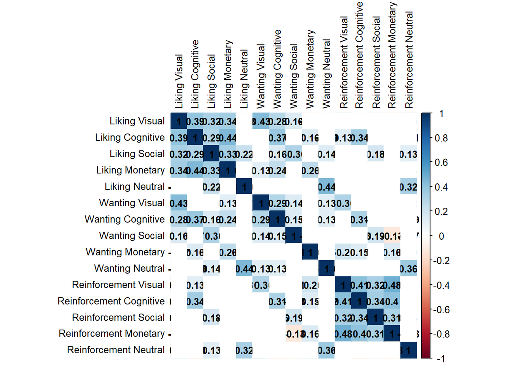

```
## R was not square, finding R from data
```

```
## $chisq
## [1] 547.8718
##
## $p.value
## [1] 4.097026e-61
##
## $df
## [1] 105
```

```
## [1] 0.03553312
```

## Experiment 3

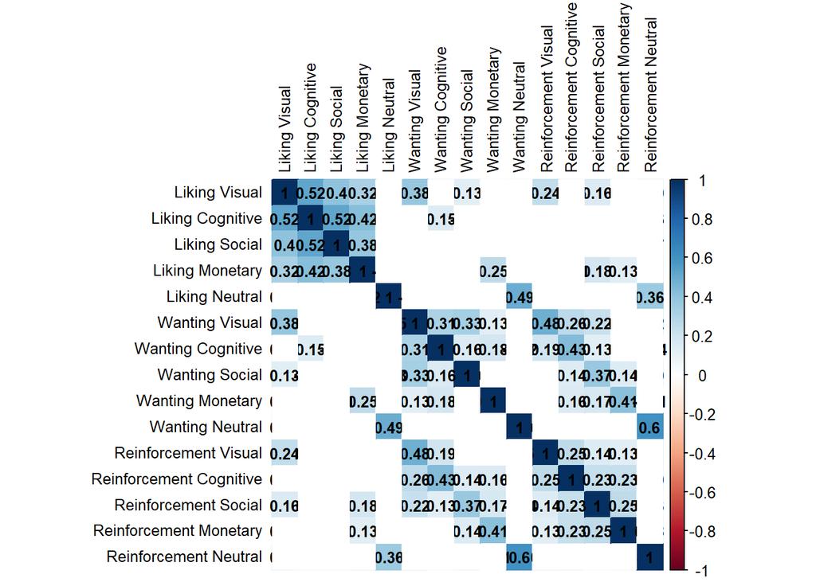

```
## R was not square, finding R from data
```

```
## $chisq
## [1] 616.8267
##
## $p.value
## [1] 1.903458e-73
##
## $df
## [1] 105
```

```
## [1] 0.02838084
```

# Reward data factor analysis

## Experiment 1

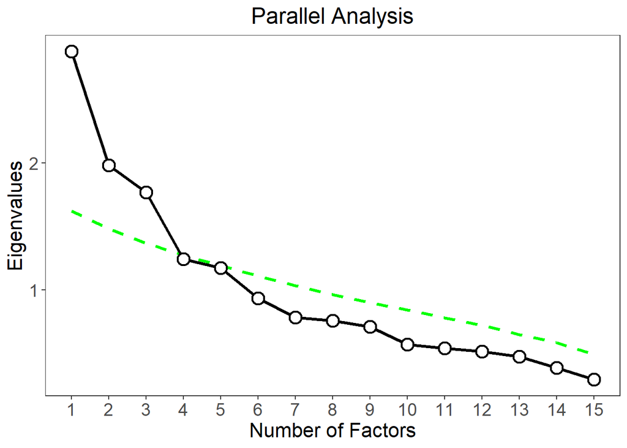

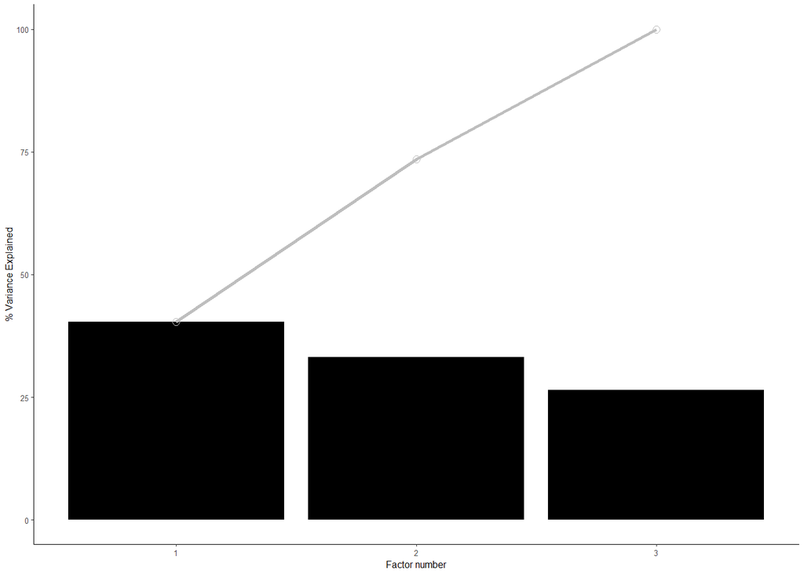

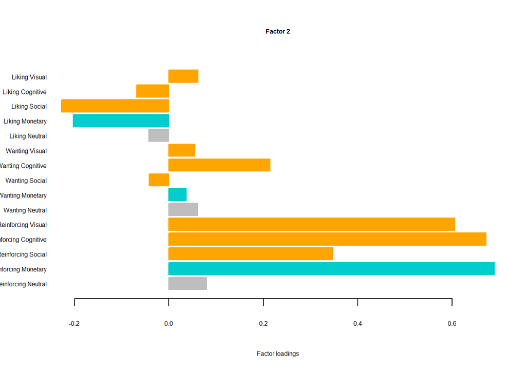

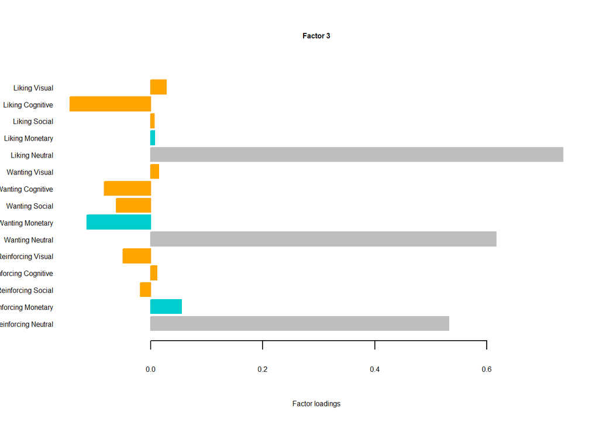

```
##
## Call:
## lm(formula = mentalHealth_NoOutlier ~ gender + age + iq + edu +
##     income + rewardSensitivity_NoOutlier, data = df)
##
## Residuals:
##      Min       1Q   Median       3Q      Max
## -2.25655 -0.44520  0.09413  0.66172  1.85336
##
## Coefficients:
##                              Estimate Std. Error t value Pr(>|t|)
## (Intercept)                  0.556795   0.428842   1.298  0.19683
## gender                      -0.149403   0.193523  -0.772  0.44173
## age                         -0.010379   0.008679  -1.196  0.23425
## iq                          -0.035683   0.028043  -1.272  0.20586
## edu                          0.031317   0.059389   0.527  0.59901
## income                       0.040980   0.048882   0.838  0.40361
## rewardSensitivity_NoOutlier  0.255624   0.090129   2.836  0.00542 **
## ---
## Signif. codes:  0 '***' 0.001 '**' 0.01 '*' 0.05 '.' 0.1 ' ' 1
##
## Residual standard error: 0.9534 on 112 degrees of freedom
##   (1 observation deleted due to missingness)
## Multiple R-squared:  0.09895,    Adjusted R-squared:  0.05068
## F-statistic:  2.05 on 6 and 112 DF,  p-value: 0.06482
```

```
##
## Call:
## lm(formula = mentalHealth_NoOutlier ~ rewardSensitivity_NoOutlier,
##     data = df)
##
## Residuals:
##     Min      1Q  Median      3Q     Max
## -2.4236 -0.5082  0.1604  0.6623  1.8840
##
## Coefficients:
##                              Estimate Std. Error t value Pr(>|t|)
## (Intercept)                 4.580e-17  8.899e-02   0.000   1.0000
## rewardSensitivity_NoOutlier 2.403e-01  8.936e-02   2.689   0.0082 **
## ---
## Signif. codes:  0 '***' 0.001 '**' 0.01 '*' 0.05 '.' 0.1 ' ' 1
##
## Residual standard error: 0.9748 on 118 degrees of freedom
## Multiple R-squared:  0.05775,    Adjusted R-squared:  0.04977
## F-statistic: 7.233 on 1 and 118 DF,  p-value: 0.008195
```

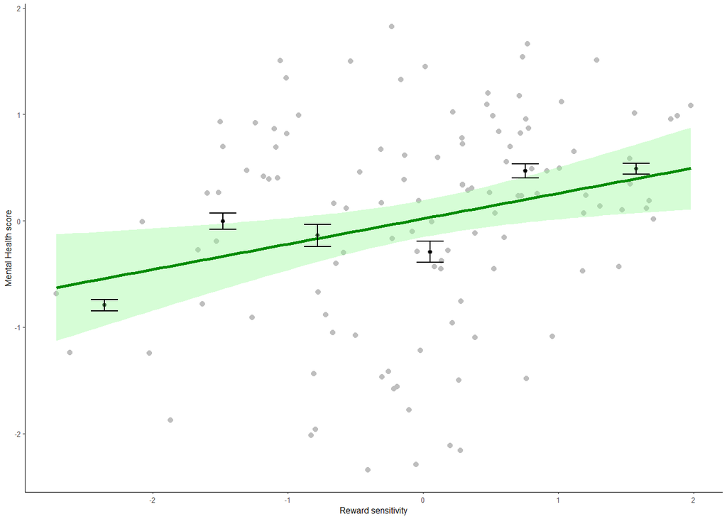

```
##                       statistic   p_value
## linearity test         1.176664 0.3119579
## homoscedasticity test  2.040594 0.1531498
```

## Experiment 2

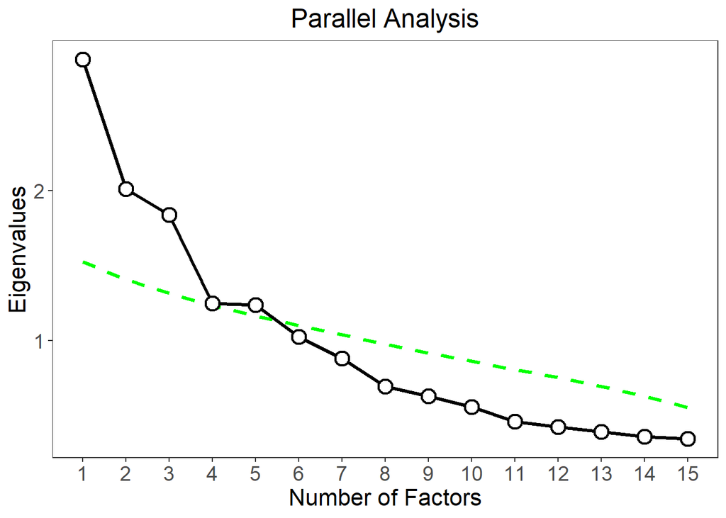

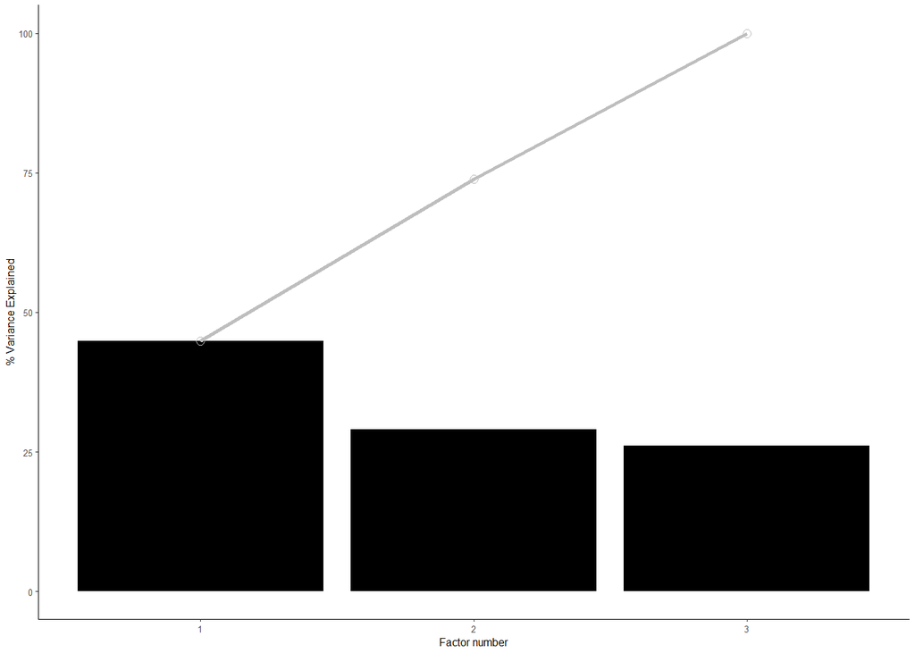

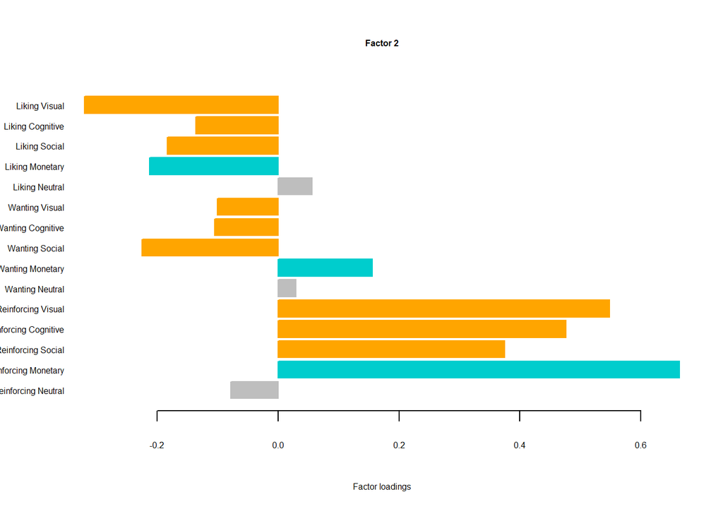

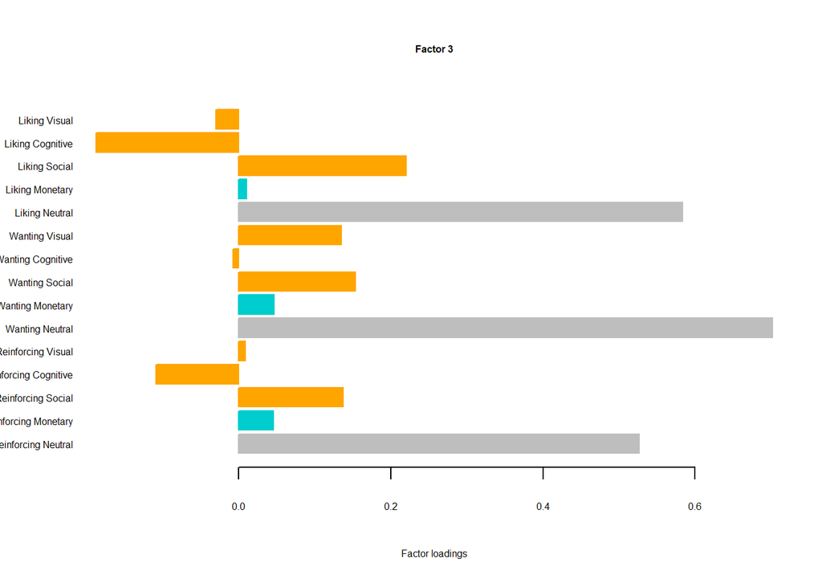

```
##
## Call:
## lm(formula = mentalHealth_NoOutlier ~ gender + age + iq + edu +
##     income + rewardSensitivity_NoOutlier, data = df)
##
## Residuals:
##     Min      1Q  Median      3Q     Max
## -2.4645 -0.6262  0.1647  0.6928  1.6859
##
## Coefficients:
##                              Estimate Std. Error t value Pr(>|t|)
## (Intercept)                 -0.627415   0.272215  -2.305   0.0226 *
## gender                       0.022165   0.149793   0.148   0.8826
## age                          0.011900   0.005521   2.155   0.0327 *
## iq                          -0.049905   0.023972  -2.082   0.0391 *
## edu                          0.118576   0.049104   2.415   0.0170 *
## income                       0.093094   0.036462   2.553   0.0117 *
## rewardSensitivity_NoOutlier  0.181157   0.074546   2.430   0.0163 *
## ---
## Signif. codes:  0 '***' 0.001 '**' 0.01 '*' 0.05 '.' 0.1 ' ' 1
##
## Residual standard error: 0.9129 on 149 degrees of freedom
##   (1 observation deleted due to missingness)
## Multiple R-squared:  0.1895, Adjusted R-squared:  0.1568
## F-statistic: 5.805 on 6 and 149 DF,  p-value: 1.853e-05
```

```
##
## Call:
## lm(formula = mentalHealth_NoOutlier ~ rewardSensitivity_NoOutlier,
##     data = df)
##
## Residuals:
##     Min      1Q  Median      3Q     Max
## -2.5971 -0.6869  0.1204  0.7917  1.7467
##
## Coefficients:
##                              Estimate Std. Error t value Pr(>|t|)
## (Intercept)                 7.446e-18  7.880e-02   0.000   1.0000
## rewardSensitivity_NoOutlier 1.769e-01  7.905e-02   2.238   0.0266 *
## ---
## Signif. codes:  0 '***' 0.001 '**' 0.01 '*' 0.05 '.' 0.1 ' ' 1
##
## Residual standard error: 0.9874 on 155 degrees of freedom
## Multiple R-squared:  0.0313, Adjusted R-squared:  0.02505
## F-statistic: 5.009 on 1 and 155 DF,  p-value: 0.02664
```

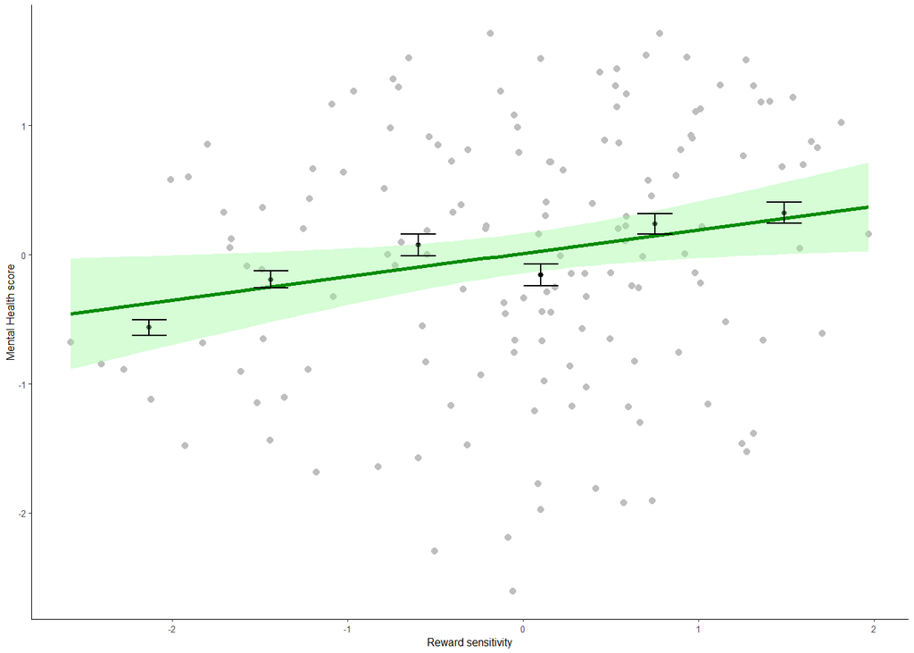

```
##                       statistic   p_value
## linearity test        0.8391840 0.4340417
## homoscedasticity test 0.4846324 0.4863315
```

## Experiment 3

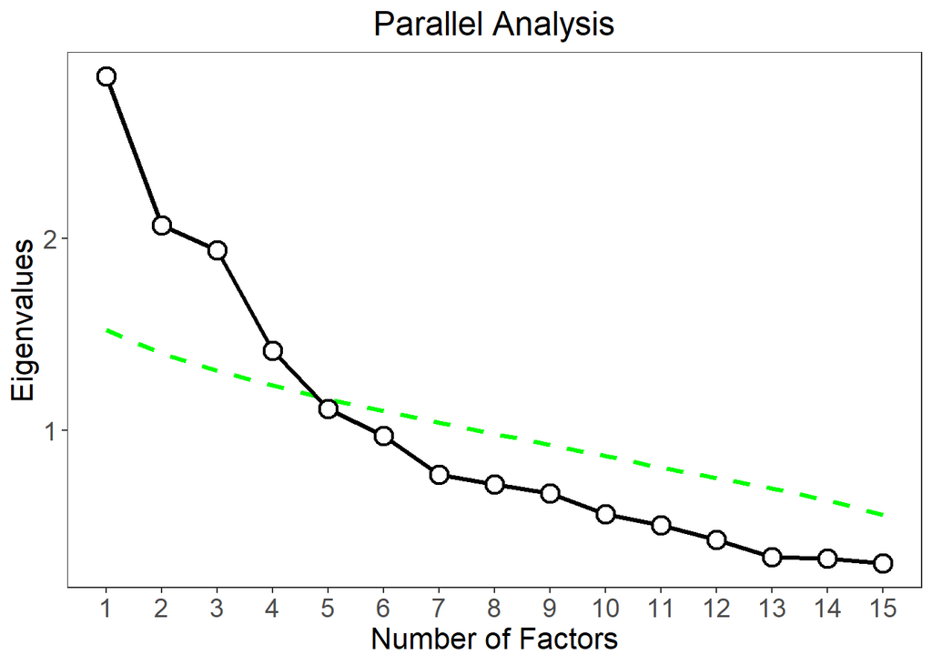

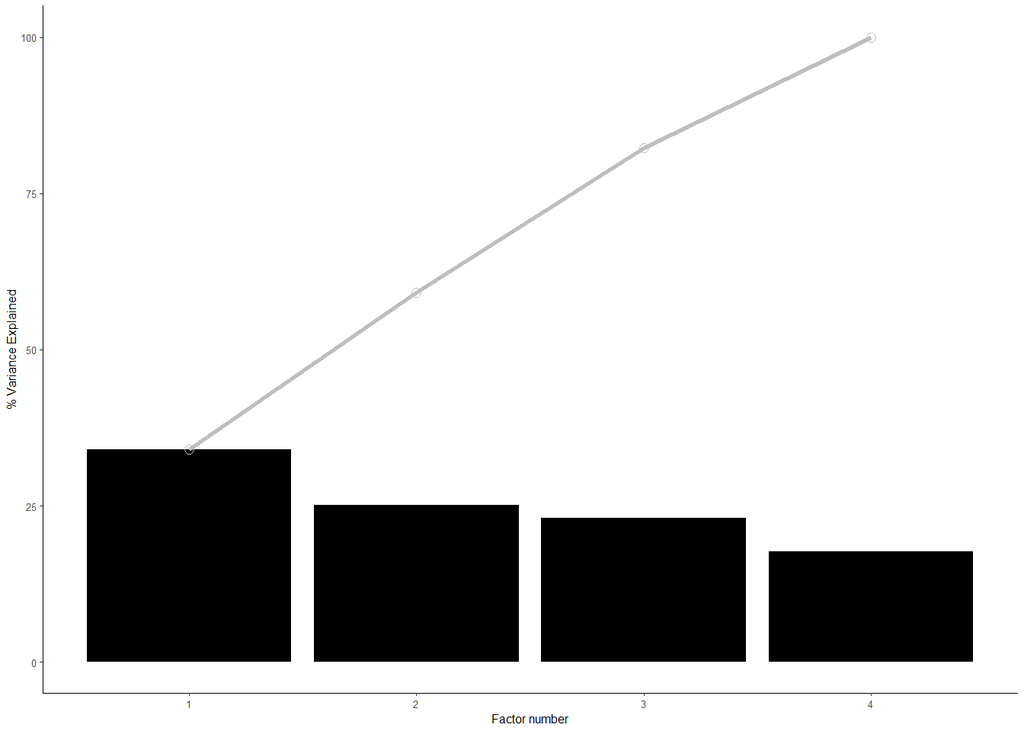

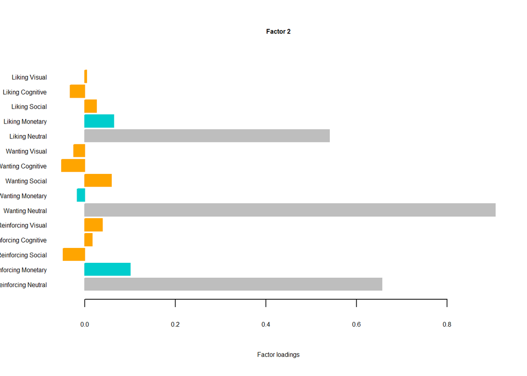

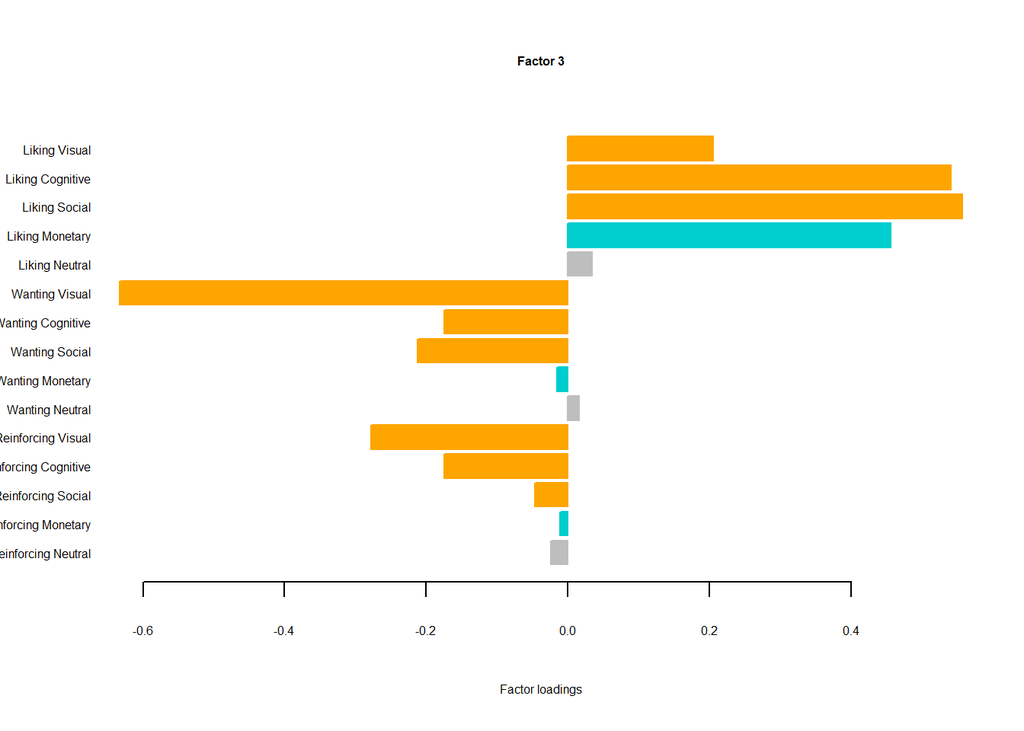

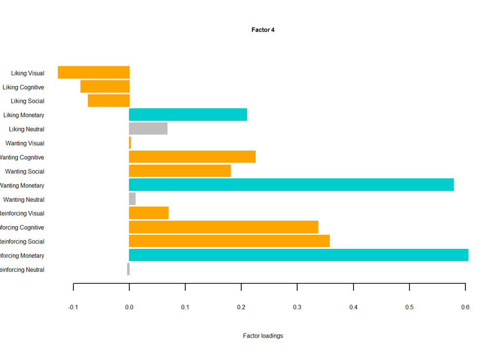

```
##
## Call:
## lm(formula = mentalHealth_NoOutlier ~ gender + age + iq + edu +
##     income + rewardSensitivity_NoOutlier, data = df)
##
## Residuals:
##      Min       1Q   Median       3Q      Max
## -2.35795 -0.56553  0.06188  0.78417  1.82144
##
## Coefficients:
##                              Estimate Std. Error t value Pr(>|t|)
## (Intercept)                 -0.498377   0.389075  -1.281  0.20226
## gender                       0.071558   0.164879   0.434  0.66493
## age                          0.006643   0.007296   0.911  0.36402
## iq                          -0.029033   0.023754  -1.222  0.22361
## edu                          0.097087   0.048445   2.004  0.04692 *
## income                       0.041779   0.047949   0.871  0.38502
## rewardSensitivity_NoOutlier  0.261735   0.077784   3.365  0.00098 ***
## ---
## Signif. codes:  0 '***' 0.001 '**' 0.01 '*' 0.05 '.' 0.1 ' ' 1
##
## Residual standard error: 0.9537 on 145 degrees of freedom
##   (2 observations deleted due to missingness)
## Multiple R-squared:  0.1199, Adjusted R-squared:  0.08345
## F-statistic: 3.291 on 6 and 145 DF,  p-value: 0.004577
```

```
##
## Call:
## lm(formula = mentalHealth_NoOutlier ~ rewardSensitivity_NoOutlier,
##     data = df)
##
## Residuals:
##     Min      1Q  Median      3Q     Max
## -2.5172 -0.6603  0.0491  0.7662  1.6429
##
## Coefficients:
##                               Estimate Std. Error t value Pr(>|t|)
## (Intercept)                 -7.744e-18  7.800e-02   0.000  1.00000
## rewardSensitivity_NoOutlier  2.628e-01  7.826e-02   3.359  0.00099 ***
## ---
## Signif. codes:  0 '***' 0.001 '**' 0.01 '*' 0.05 '.' 0.1 ' ' 1
##
## Residual standard error: 0.968 on 152 degrees of freedom
## Multiple R-squared:  0.06909,    Adjusted R-squared:  0.06296
## F-statistic: 11.28 on 1 and 152 DF,  p-value: 0.0009901
```

```
##                                                RewardFactorCoefficients
## Experiment 1, Controlling for demographics                    0.2556242
## Experiment 1, not controlling for demographics                0.2403224
## Experiment 2, Controlling for demographics                    0.1811570
## Experiment 2, not controlling for demographics                0.1769279
## Experiment 3, Controlling for demographics                    0.2617348
## Experiment 3, not controlling for demographics                0.2628431
##                                                standard_errors
## Experiment 1, Controlling for demographics          0.09012880
## Experiment 1, not controlling for demographics      0.08935955
## Experiment 2, Controlling for demographics          0.07454625
## Experiment 2, not controlling for demographics      0.07905476
## Experiment 3, Controlling for demographics          0.07778357
## Experiment 3, not controlling for demographics      0.07825874
##                                                degrees_of_freedom t_values
## Experiment 1, Controlling for demographics                    112 2.836210
## Experiment 1, not controlling for demographics                118 2.689387
## Experiment 2, Controlling for demographics                    149 2.430129
## Experiment 2, not controlling for demographics                155 2.238043
## Experiment 3, Controlling for demographics                    145 3.364911
## Experiment 3, not controlling for demographics                152 3.358642
##                                                    p_values
## Experiment 1, Controlling for demographics     0.0054192351
## Experiment 1, not controlling for demographics 0.0081954399
## Experiment 2, Controlling for demographics     0.0162819949
## Experiment 2, not controlling for demographics 0.0266433912
## Experiment 3, Controlling for demographics     0.0009799862
## Experiment 3, not controlling for demographics 0.0009900977
```

```
##
## Call:
## lm(formula = mentalHealth_NoOutlier ~ gender + age + iq + edu +
##     income + rewardSensitivity_NoOutlier, data = df)
##
## Residuals:
##      Min       1Q   Median       3Q      Max
## -2.35795 -0.56553  0.06188  0.78417  1.82144
##
## Coefficients:
##                              Estimate Std. Error t value Pr(>|t|)
## (Intercept)                 -0.498377   0.389075  -1.281  0.20226
## gender                       0.071558   0.164879   0.434  0.66493
## age                          0.006643   0.007296   0.911  0.36402
## iq                          -0.029033   0.023754  -1.222  0.22361
## edu                          0.097087   0.048445   2.004  0.04692 *
## income                       0.041779   0.047949   0.871  0.38502
## rewardSensitivity_NoOutlier  0.261735   0.077784   3.365  0.00098 ***
## ---
## Signif. codes:  0 '***' 0.001 '**' 0.01 '*' 0.05 '.' 0.1 ' ' 1
##
## Residual standard error: 0.9537 on 145 degrees of freedom
##   (2 observations deleted due to missingness)
## Multiple R-squared:  0.1199, Adjusted R-squared:  0.08345
## F-statistic: 3.291 on 6 and 145 DF,  p-value: 0.004577
```

```
##
## Call:
## lm(formula = mentalHealth_NoOutlier ~ rewardSensitivity_NoOutlier,
##     data = df)
##
## Residuals:
##     Min      1Q  Median      3Q     Max
## -2.5172 -0.6603  0.0491  0.7662  1.6429
##
## Coefficients:
##                               Estimate Std. Error t value Pr(>|t|)
## (Intercept)                 -7.744e-18  7.800e-02   0.000  1.00000
## rewardSensitivity_NoOutlier  2.628e-01  7.826e-02   3.359  0.00099 ***
## ---
## Signif. codes:  0 '***' 0.001 '**' 0.01 '*' 0.05 '.' 0.1 ' ' 1
##
## Residual standard error: 0.968 on 152 degrees of freedom
## Multiple R-squared:  0.06909,    Adjusted R-squared:  0.06296
## F-statistic: 11.28 on 1 and 152 DF,  p-value: 0.0009901
```

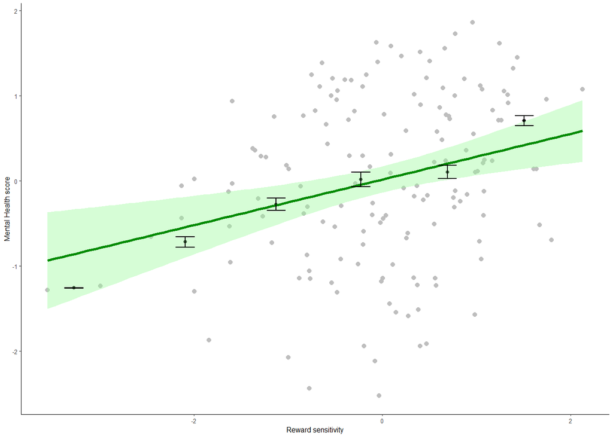

```
##                       statistic   p_value
## linearity test        0.7436151 0.4771364
## homoscedasticity test 0.1012731 0.7503071
```

# Is intrinsic reward more related to mental health than monetary reward?

## Factor analyses separately for intrinsic and monetary rewards

### Experiment 1

#### Intrinsic reward factorisation

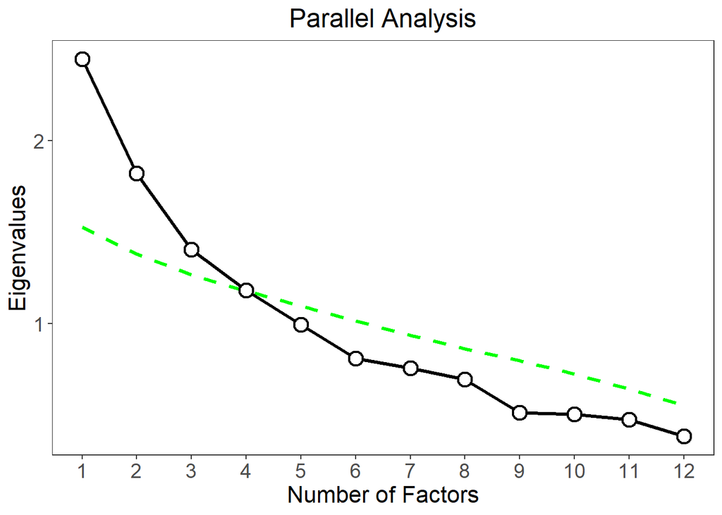

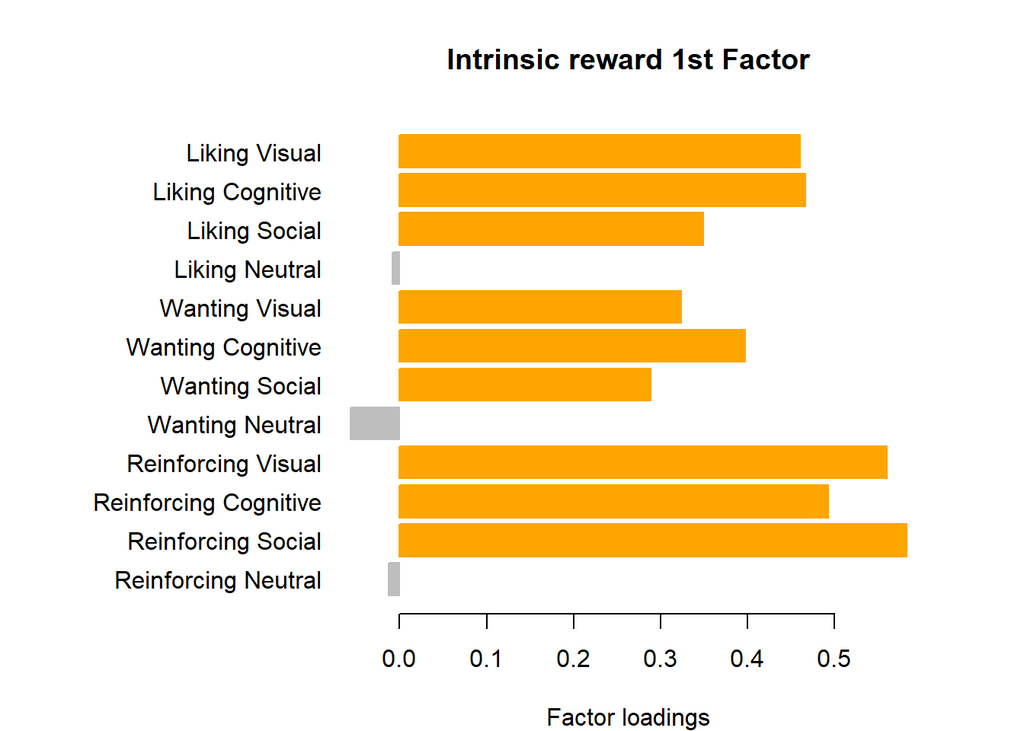

#### Monetary reward factorisation

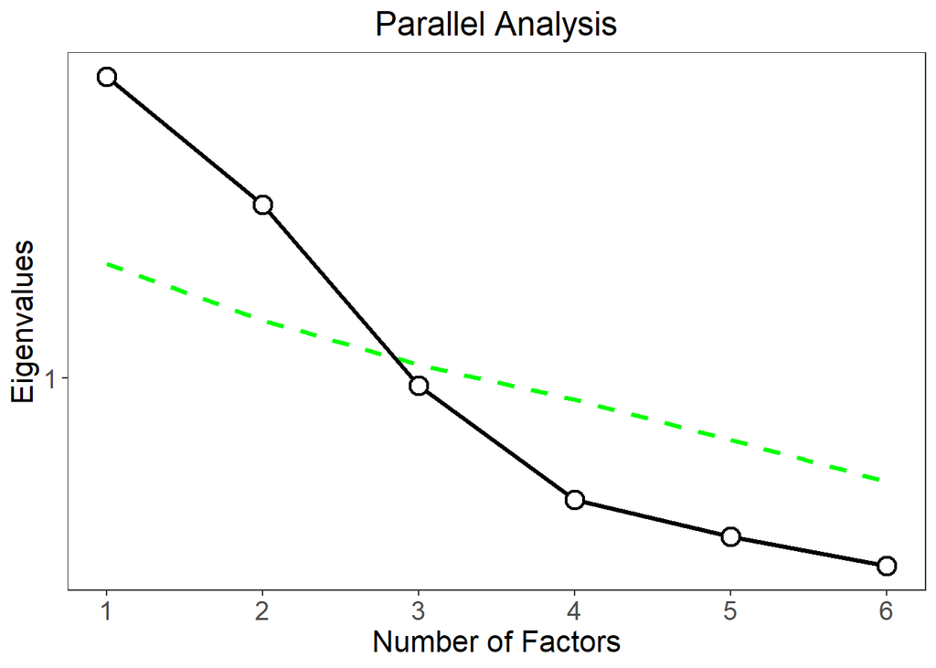

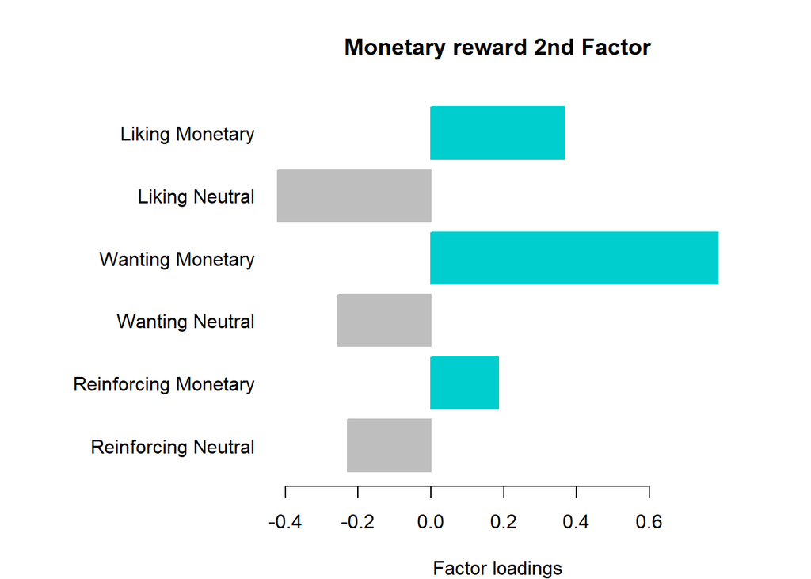

#### Relation to mental health

```
##
## Call:
## lm(formula = mentalHealth_NoOutlier ~ gender + age + iq + edu +
##     income + irSensitivity_NoOutlier + mrSensitivity_NoOutlier,
##     data = df)
##
## Residuals:
##     Min      1Q  Median      3Q     Max
## -1.7435 -0.3348  0.1067  0.5049  1.4054
##
## Coefficients:
##                          Estimate Std. Error t value Pr(>|t|)
## (Intercept)              0.509426   0.333485   1.528   0.1294
## gender                  -0.139864   0.150957  -0.927   0.3562
## age                     -0.006768   0.006675  -1.014   0.3129
## iq                      -0.023868   0.021292  -1.121   0.2647
## edu                      0.006257   0.045206   0.138   0.8902
## income                   0.046747   0.036887   1.267   0.2077
## irSensitivity_NoOutlier  0.192928   0.089177   2.163   0.0326 *
## mrSensitivity_NoOutlier  0.084387   0.111509   0.757   0.4508
## ---
## Signif. codes:  0 '***' 0.001 '**' 0.01 '*' 0.05 '.' 0.1 ' ' 1
##
## Residual standard error: 0.7287 on 112 degrees of freedom
##   (1 observation deleted due to missingness)
## Multiple R-squared:  0.08423,    Adjusted R-squared:  0.027
## F-statistic: 1.472 on 7 and 112 DF,  p-value: 0.1845
```

```
##
## Call:
## lm(formula = mentalHealth_NoOutlier ~ irSensitivity_NoOutlier +
##     mrSensitivity_NoOutlier, data = df)
##
## Residuals:
##      Min       1Q   Median       3Q      Max
## -1.83254 -0.42030  0.09585  0.52919  1.39439
##
## Coefficients:
##                         Estimate Std. Error t value Pr(>|t|)
## (Intercept)              0.10901    0.06817   1.599   0.1125
## irSensitivity_NoOutlier  0.18156    0.08736   2.078   0.0399 *
## mrSensitivity_NoOutlier  0.06156    0.10939   0.563   0.5747
## ---
## Signif. codes:  0 '***' 0.001 '**' 0.01 '*' 0.05 '.' 0.1 ' ' 1
##
## Residual standard error: 0.7423 on 118 degrees of freedom
## Multiple R-squared:  0.04426,    Adjusted R-squared:  0.02806
## F-statistic: 2.732 on 2 and 118 DF,  p-value: 0.0692
```

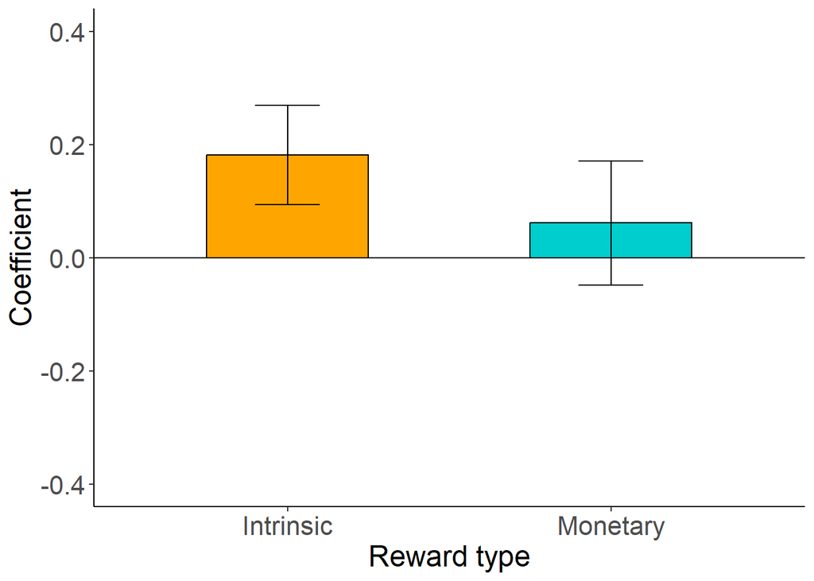

```
##
## Call:
## lm(formula = mentalHealth_NoOutlier ~ irSensitivity_NoOutlier,
##     data = df)
##
## Residuals:
##     Min      1Q  Median      3Q     Max
## -1.8310 -0.4206  0.1166  0.5227  1.4219
##
## Coefficients:
##                         Estimate Std. Error t value Pr(>|t|)
## (Intercept)              0.11380    0.06744   1.687   0.0942 .
## irSensitivity_NoOutlier  0.19288    0.08477   2.275   0.0247 *
## ---
## Signif. codes:  0 '***' 0.001 '**' 0.01 '*' 0.05 '.' 0.1 ' ' 1
##
## Residual standard error: 0.7401 on 119 degrees of freedom
## Multiple R-squared:  0.04169,    Adjusted R-squared:  0.03364
## F-statistic: 5.177 on 1 and 119 DF,  p-value: 0.02468
```

```
##
## Call:
## lm(formula = mentalHealth_NoOutlier ~ gender + age + iq + edu +
##     income + irSensitivity_NoOutlier, data = df)
##
## Residuals:
##      Min       1Q   Median       3Q      Max
## -1.71378 -0.32547  0.09592  0.52372  1.44358
##
## Coefficients:
##                          Estimate Std. Error t value Pr(>|t|)
## (Intercept)              0.524271   0.332277   1.578   0.1174
## gender                  -0.118304   0.147964  -0.800   0.4257
## age                     -0.006686   0.006662  -1.004   0.3177
## iq                      -0.025529   0.021139  -1.208   0.2297
## edu                      0.002153   0.044794   0.048   0.9618
## income                   0.047930   0.036784   1.303   0.1952
## irSensitivity_NoOutlier  0.206425   0.087210   2.367   0.0196 *
## ---
## Signif. codes:  0 '***' 0.001 '**' 0.01 '*' 0.05 '.' 0.1 ' ' 1
##
## Residual standard error: 0.7273 on 113 degrees of freedom
##   (1 observation deleted due to missingness)
## Multiple R-squared:  0.07955,    Adjusted R-squared:  0.03067
## F-statistic: 1.628 on 6 and 113 DF,  p-value: 0.1459
```

```
##
## Call:
## lm(formula = mentalHealth_NoOutlier ~ mrSensitivity_NoOutlier,
##     data = df)
##
## Residuals:
##     Min      1Q  Median      3Q     Max
## -1.9917 -0.3444  0.1767  0.5388  1.3177
##
## Coefficients:
##                         Estimate Std. Error t value Pr(>|t|)
## (Intercept)              0.11419    0.06907   1.653    0.101
## mrSensitivity_NoOutlier  0.11390    0.10792   1.055    0.293
##
## Residual standard error: 0.7526 on 119 degrees of freedom
## Multiple R-squared:  0.009274,   Adjusted R-squared:  0.0009485
## F-statistic: 1.114 on 1 and 119 DF,  p-value: 0.2934
```

```
##
## Call:
## lm(formula = mentalHealth_NoOutlier ~ gender + age + iq + edu +
##     income + mrSensitivity_NoOutlier, data = df)
##
## Residuals:
##     Min      1Q  Median      3Q     Max
## -1.8877 -0.3783  0.1998  0.5054  1.2943
##
## Coefficients:
##                          Estimate Std. Error t value Pr(>|t|)
## (Intercept)              0.384812   0.333779   1.153    0.251
## gender                  -0.069638   0.149807  -0.465    0.643
## age                     -0.005563   0.006760  -0.823    0.412
## iq                      -0.019707   0.021548  -0.915    0.362
## edu                      0.010348   0.045896   0.225    0.822
## income                   0.047432   0.037482   1.265    0.208
## mrSensitivity_NoOutlier  0.132632   0.111021   1.195    0.235
##
## Residual standard error: 0.7404 on 113 degrees of freedom
##   (1 observation deleted due to missingness)
## Multiple R-squared:  0.04596,    Adjusted R-squared:  -0.004696
## F-statistic: 0.9073 on 6 and 113 DF,  p-value: 0.4924
```

```
## [1] 295.2102
```

```
## [1] 299.511
```

```
## [1] 0
```

```
## [1] 4.300775
```

```
## [1] 282.9349
```

```
## [1] 286.9604
```

```
## [1] 0
```

```
## [1] 4.025515
```